# Week 2 exercises

Dmitry Kondrashov and Stefano Allesina

## Goals:

In this assignment you will do the following:

- Calculate conditional probabilities from data sets in tibble format using logical statements
- Use probability distribution functions and random number generators for calculations
- Generate sample means and calculate confidence intervals to investigate their performance

## Grading:

Part 1: 3 pts each, 6 total Part 2: 4 pts each, 12 total Part 3: 5 pts each, 10 total + 2 pts for submission Total: 30 pts

## Part 1: Conditional probabilities

Let us use the Titanic passenger data set, specifically the titanic_train tibble:

```r
library(titanic)
head(titanic_train)
```

```
##   PassengerId Survived Pclass
## 1           1        0      3
## 2           2        1      1
## 3           3        1      3
## 4           4        1      1
## 5           5        0      3
## 6           6        0      3
##                                                  Name    Sex Age SibSp
## 1                             Braund, Mr. Owen Harris   male  22     1
## 2 Cumings, Mrs. John Bradley (Florence Briggs Thayer) female  38     1
## 3                              Heikkinen, Miss. Laina female  26     0
## 4        Futrelle, Mrs. Jacques Heath (Lily May Peel) female  35     1
## 5                            Allen, Mr. William Henry   male  35     0
## 6                                    Moran, Mr. James   male  NA     0
##   Parch           Ticket    Fare Cabin Embarked
## 1     0        A/5 21171  7.2500              S
## 2     0         PC 17599 71.2833   C85        C
## 3     0 STON/O2. 3101282  7.9250              S
## 4     0           113803 53.1000  C123        S
## 5     0           373450  8.0500              S
## 6     0           330877  8.4583              Q
```

1. Calculate and report the conditional probability of survival for men and women and compare with the survival probability for all passengers.
2. Suppose there is a hypothesis that the difference in survival rates for different passenger classes is due to different fractions of males and females. To check if this is plausible, calculate the survival rates for males and females separately for the three passenger classes and state your conclusions.

## Part 2: Distributions and their properties

Use scripts from the Tuesday lecture.Rmd file to plot the distributions and calculate their expectations and variances and compare them to the theoretical predictions.

1. Uniform distribution (discrete). Plot the distribution over the ranges [0,20] and [-10, 30], report the respective expectations and variances and compare them to the theoretical values (look it up if you can’t calculate or deduce the relationship by experimenting).
2. Binomial distribution. Plot the distribution for n=20 and p=0.3, for n=10 and p=0.6, and for n= 40 and p = 0.5; report the respective expectations and variances and compare them to theoretical dependence on n and p (look it up if you can’t calculate or deduce the relationship by experimenting).
3. Geometric distribution. Plot the distribution for p=0.2, p = 0.5, and p=0.7, report the respective expectations and variances and compare them to theoretical dependence on p (look it up if you can’t calculate or deduce the relationship by experimenting).

## Part 3: Confidence intervals vs reality

1. The script below generates samples from the discrete uniform distribution between 0 and 10, plots the distribution of sample means, and compared it with the normal distribution with the theoretical mean and standard error. Modify the script to produce samples from the binomial distribution with different values of p and n, and report how well the sample means agree with the theoretical normal distribution. Remember to change the calculations for mu and sigma.

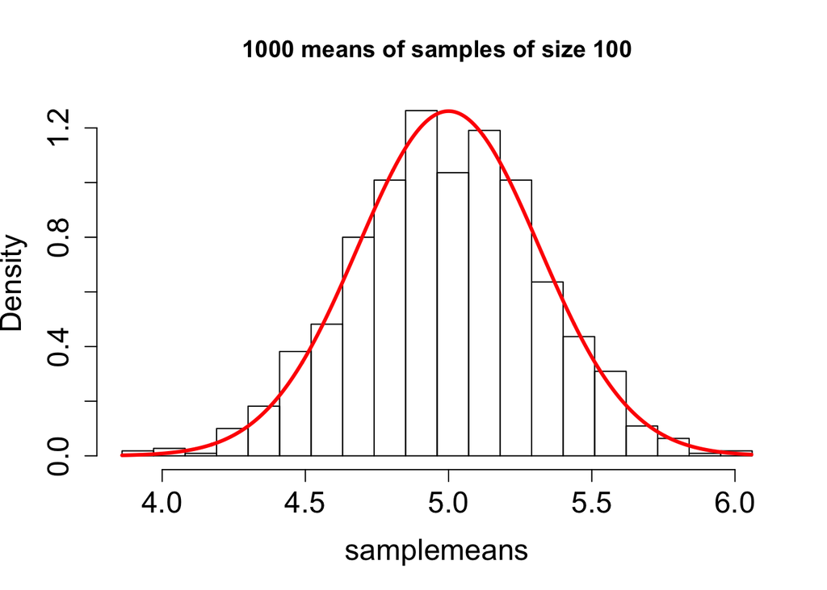

```r
#
numsamples <- 1000
samplemeans<-rep(NA, numsamples)
size<-100
low <- 0
high <- 10
for (i in 1:numsamples) {
  sample <- sample(low:high,size,replace=TRUE)
  samplemeans[i] <- mean(sample)
}
break_points <- seq(min(samplemeans),max(samplemeans),
                    (max(samplemeans)-min(samplemeans))/20)
hist(samplemeans, breaks=break_points, freq=FALSE, cex.axis=1.5, cex.lab=1.5,
     main= paste(numsamples, 'means of samples of size', size))
sigma<-sqrt(((high-low+1)^2-1)/12)/sqrt(size) # standard error for the distribution
mu<-(high-low)/2 # true mean of the distribution
range <- seq(min(samplemeans),max(samplemeans), sigma/100)
lines(range,dnorm(range,mu,sigma),t='l',lwd=3,col=2,lty=1,cex.axis=1.5,cex.lab=1.5)
```

2. The following script calculates a confidence interval based on a sample. The z-value is the width of the interval measured in multiples of standard deviations of the normal distribution (standard errors) required for the interval to contain the probability density equal to the significance level $\alpha$, which theoretically should be the fraction of confidence intervals (out of many) that contain the true mean.

Modify the script to report whether the confidence interval contains the true mean. Use a loop structure (as in the script above) to generate 1000 sample means and report how many of them are within the theoretical confidence interval. Does this match the fraction you expect from the significance level? Try different significance levels and sample sizes and report what you discover.

```r
# Computing confidence intervals
size <- 100 # sample size
alpha <- 0.95 # significance level
sample<-runif(size)
s <- sd(sample)/sqrt(size) # standard error
z <- qnorm((1-alpha)/2) # z-value
left <- mean(sample)+s*z
right <- mean(sample)-s*z
paste("(", left, ",", right, ")")
```

```
## [1] "( 0.39559295189022 , 0.506859613159533 )"
```